# Estudo de caso: Alunos do curso de biologia do Rio de Janeiro

### 2017-10-16

```
## A interface gráfica do Rcmdr só é lançada no modo interativo
```

Introdução.

Este estudo de caso busca com o auxilio da plataforma R definir um perfil dos estudantes de biologia do Estado do Rio de Janeiro, procurando definir quais são os fatores para os alunos gostarem ou não de biologia.

Objetivos

Fazer o perfil do aluno do curso de biologia do Estado do Rio de Janeiro e tentar descobrir quais os fatores impactam no gostar/não gostar de biologia.

Metodologia.

Analise dos dados, identificação das variáveis explicativas e criação de gráficos e diagramas usando a plataforma R.

Discussão:

Variávies quantitativas: Idade e gosta de estudar biologia.

Variáveis qualitativas: Raça, sexo, classe, tipo de escola e turma.

```r
> alunosbio <- readXL("C:/Users/Steven/Downloads/CASO BIOESTATISTICA/TurmasdoBiologiaRJ.xlsx", rownames=FALSE, header=TRUE,
+   na="", sheet="science", stringsAsFactors=TRUE)
```

```r
> library(colorspace, pos=16)
```

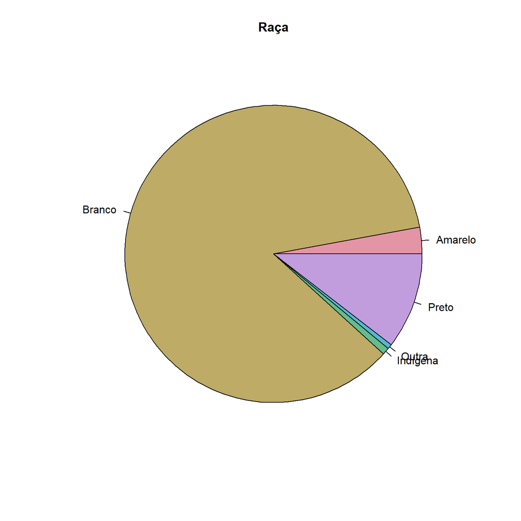

```r
> with(alunosbio, pie(table(Raça), labels=levels(Raça), xlab="", ylab="", main="Raça",
+   col=rainbow_hcl(5)))
```

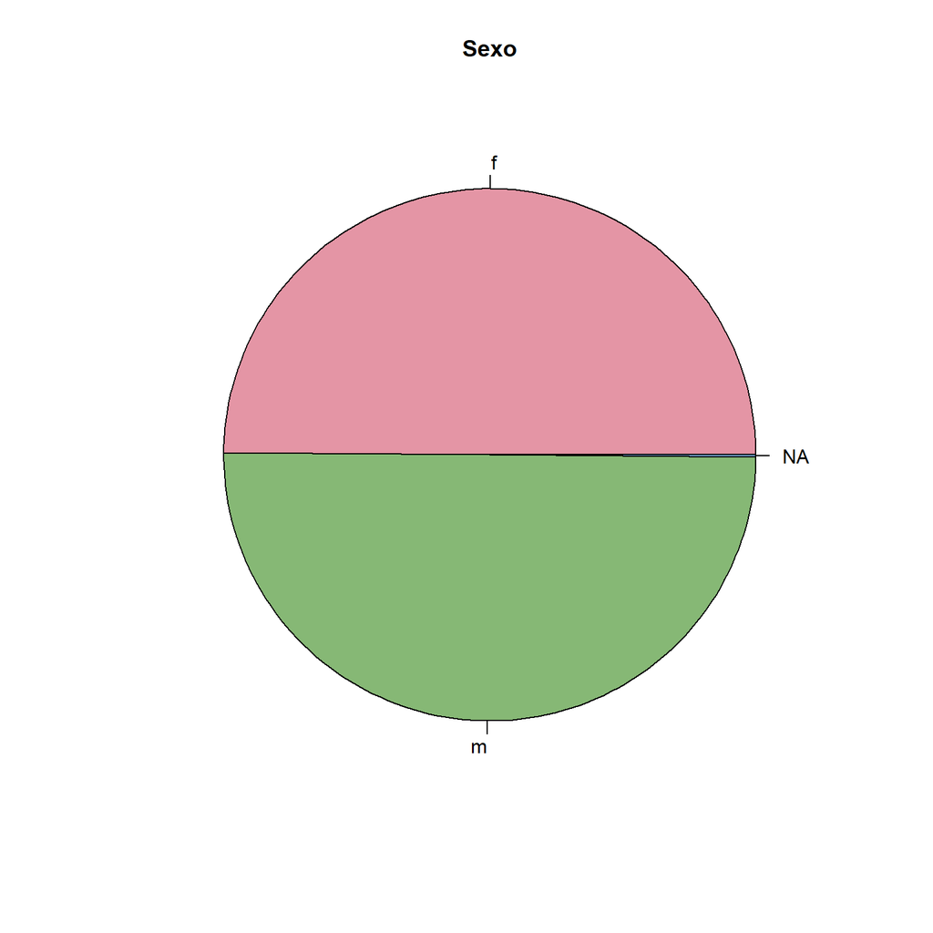

```r
> with(alunosbio, pie(table(Sexo), labels=levels(Sexo), xlab="", ylab="", main="Sexo",
+   col=rainbow_hcl(3)))
```

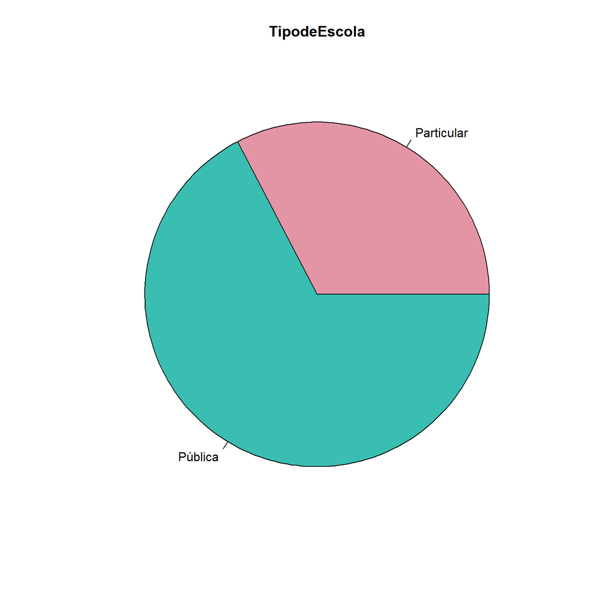

```r
> with(alunosbio, pie(table(TipodeEscola), labels=levels(TipodeEscola), xlab="", ylab="",
+   main="TipodeEscola", col=rainbow_hcl(2)))
```

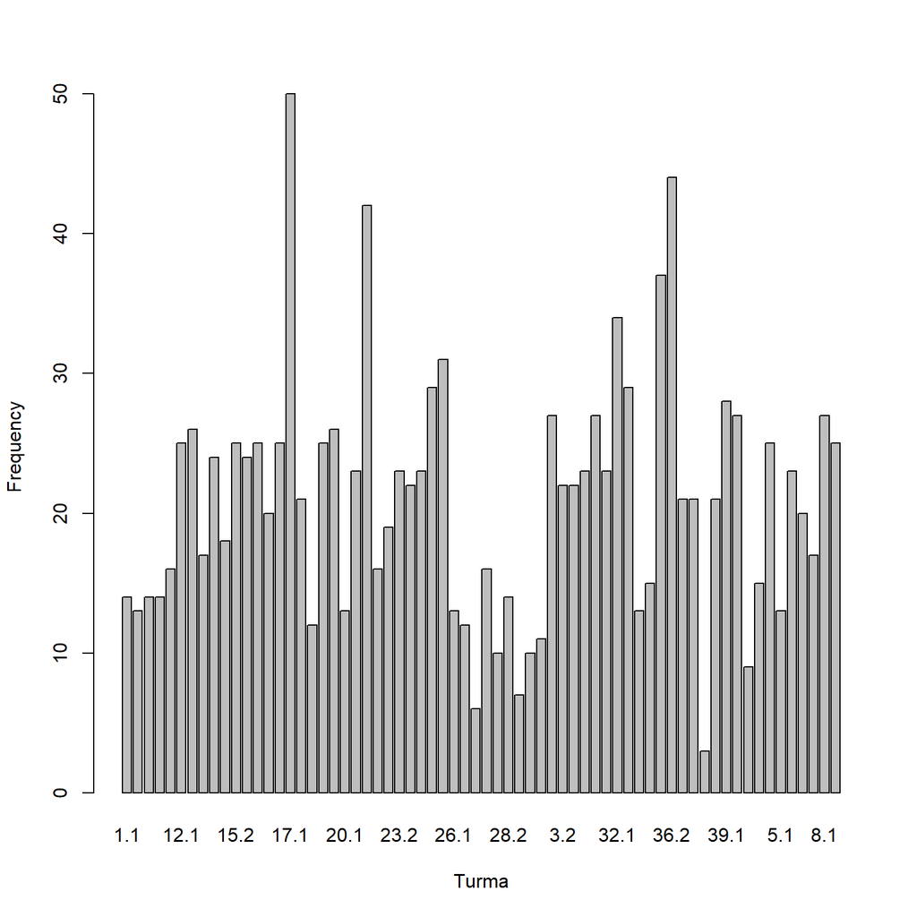

```r
> with(alunosbio, Barplot(Turma, xlab="Turma", ylab="Frequency"))
```

```r
> summary(alunosbio)
```

```
     Aluno         State          TipodeEscola     Escola
 Min.   :   1.0   RJ  :1336   Particular:452   Min.   : 1.00
 1st Qu.: 380.0   SP  :  49   Pública   :933   1st Qu.:13.00
 Median : 760.0   NA's: 883   NA's      :883   Median :21.00
 Mean   : 766.6                                Mean   :21.16
 3rd Qu.:1157.0                                3rd Qu.:31.00
 Max.   :1544.0                                Max.   :41.00
 NA's   :883                                   NA's   :883
 Classe.1.manhã..2...Tarde..3.Noite.4.Integral.   Sexo
 Min.   :1.000                                  f   :691
 1st Qu.:1.000                                  m   :692
 Median :1.000                                  NA  :  2
 Mean   :1.527                                  NA's:883
 3rd Qu.:2.000
 Max.   :4.000
 NA's   :883
 Gosta.de.Estudar.Biologia     Turma          IDADE             Raça
 Min.   :1.000             17.1   :  50   Min.   :17.00   Amarelo :  40
 1st Qu.:4.000             36.2   :  44   1st Qu.:21.00   Branco  :1182
 Median :5.000             21.1   :  42   Median :24.00   Indígena:  11
 Mean   :5.082             36.1   :  37   Mean   :23.53   Outra   :   7
 3rd Qu.:6.000             32.1   :  34   3rd Qu.:26.00   Preto   : 145
 Max.   :8.000             (Other):1178   Max.   :27.00   NA's    : 883
 NA's   :883               NA's   : 883   NA's   :883
```

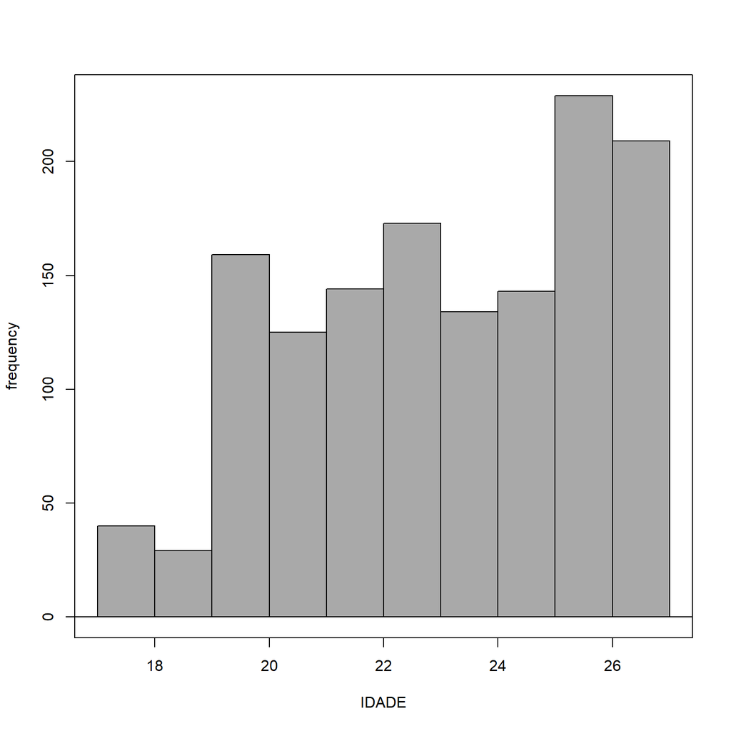

```r
> with(alunosbio, Hist(IDADE, scale="frequency", breaks="Sturges", col="darkgray"))
```

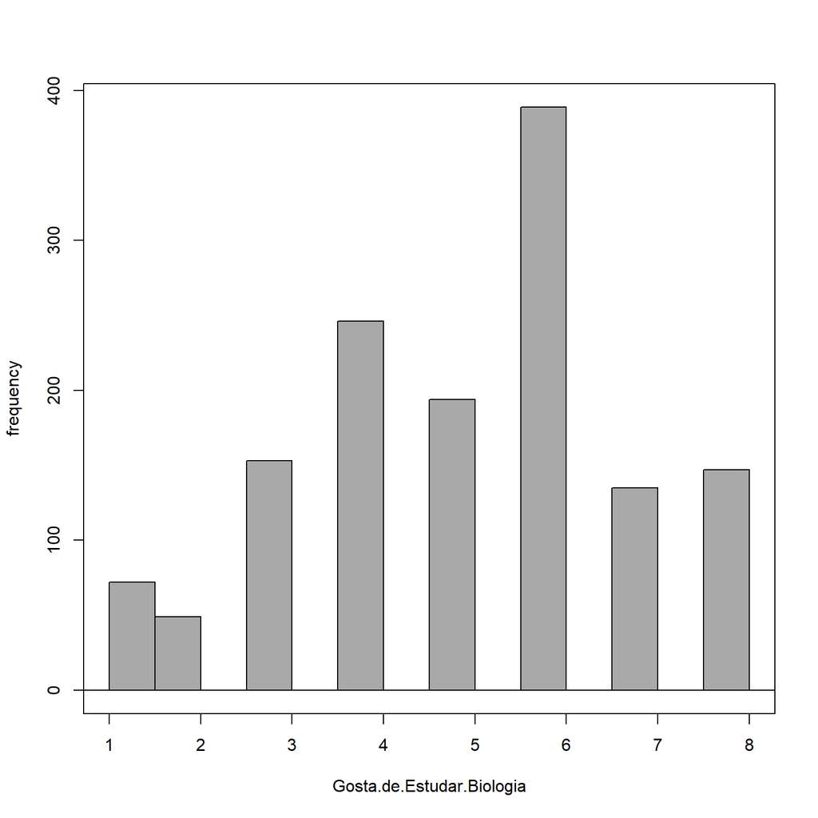

```r
> with(alunosbio, Hist(Gosta.de.Estudar.Biologia, scale="frequency", breaks="Sturges",
+   col="darkgray"))
```

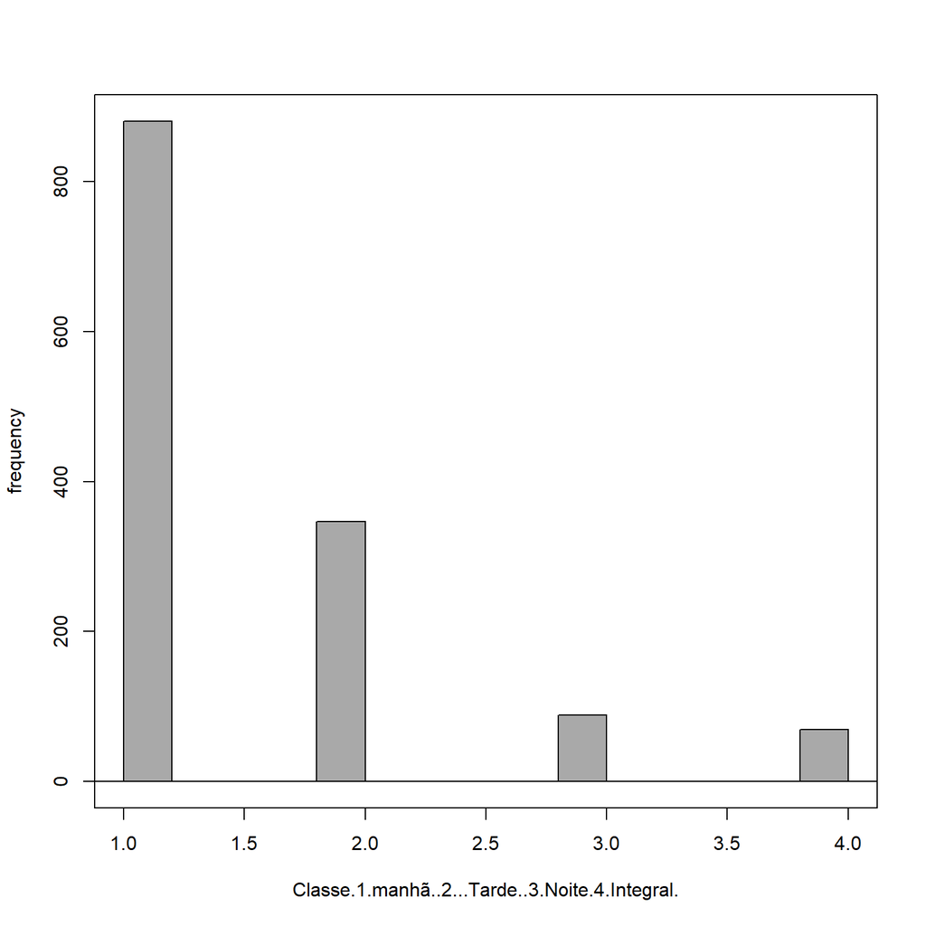

```r
> with(alunosbio, Hist(Classe.1.manhã..2...Tarde..3.Noite.4.Integral., scale="frequency",
+   breaks="Sturges", col="darkgray"))
```